# CH12: Confidence Intervals with Bootstrapping

```r
library(tidyverse)
library(janitor)
library(infer)
```

### Description and Question

People who are donating an organ may seek the help of a specialist medical consultant to reduce the risk of complications during surgery and recovery. Such people might choose a consultant based in part on the past complication rate among the consultant’s clients. One consultant advertises that the average complication rate for liver donor surgeries in the US is about 10%, but only 3 of her 62 liver donation clients have had complications. She claims this is strong evidence that her work meaningfully contributes to reducing complications—and therefore she should be hired!

Research question: “Is it reasonable to believe that the long-run risk of complications among the consultant’s patients is less than the national rate of 10%?”

### Explore the Dataset

#### Load Data and Glimpse

```r
# create the dataset

livercomp <- tibble(
  ID = 1:62,
  complication = rep(c("no", "yes"), times = c(59, 3))
)
glimpse(livercomp)
```

```
Rows: 62
Columns: 2
$ ID           <int> 1, 2, 3, 4, 5, 6, 7, 8, 9, 10, 11, 12, 13, 14, 15, 16, 17…
$ complication <chr> "no", "no", "no", "no", "no", "no", "no", "no", "no", "no…
```

#### Summarize and Visualize

```r
# make a frequency table using the janitor package

livercomp |>
  tabyl(complication) |>
  adorn_rounding(digits = 3)
```

```
 complication  n percent
           no 59   0.952
          yes  3   0.048
```

### Bootstrap CI Using an Applet

Rossman-Chance One-Sample Bootstrap Applet: https://www.rossmanchance.com/applets/2021/sampling/OneSample.html?population=bootstrap?hideExtras=1

### Bootstrap CI Using `infer` Package

#### Find the Observed Proportion

```r
# compute the observed proportion in the dataset

obs_prop <- livercomp |>
  specify(response = complication, success = "yes") |>
  calculate(stat = "prop")

obs_prop
```

```
Response: complication (factor)
# A tibble: 1 × 1
    stat
   <dbl>
1 0.0484
```

#### Explore One Bootstrap Resample

```r
# perform one bootstrap resample from the data
# note that we do not use a hypothesize for CIs
# we are estimating the parameter, not testing

bootsample_1 <- livercomp |>
  specify(response = complication, success = "yes") |>
  generate(reps = 1, type = "bootstrap")

# tabulate the boostrap resample response data

bootsample_1 |>
  tabyl(complication) |>
  adorn_rounding(digits = 3)
```

```
 complication  n percent
           no 61   0.984
          yes  1   0.016
```

#### Create the Bootstrap Distribution

```r
# generate the bootstrap distribution of the statistic
# do 1000 random bootstrap and compute the proportion

boot_dist <- livercomp |>
  specify(response = complication, success = "yes") |>
  generate(reps = 1000, type = "bootstrap") |>
  calculate(stat = "prop")

head(boot_dist)
```

```
Response: complication (factor)
# A tibble: 6 × 2
  replicate   stat
      <int>  <dbl>
1         1 0.0806
2         2 0.0484
3         3 0.0645
4         4 0
5         5 0.0161
6         6 0.0323
```

```r
boot_dist |>
  tabyl(stat) |>
  adorn_rounding(digits = 3)
```

```
       stat   n percent
 0.00000000  46   0.046
 0.01612903 147   0.147
 0.03225806 220   0.220
 0.04838710 236   0.236
 0.06451613 166   0.166
 0.08064516 100   0.100
 0.09677419  56   0.056
 0.11290323  22   0.022
 0.12903226   6   0.006
 0.16129032   1   0.001
```

#### Create the Confidence (Percentile) Interval

```r
# calculate the 95% percentile interval
# lower boundary is the 2.5 percentile
# upper boundary is the 97.5 percentile

percentile_95ci <- boot_dist |>
  get_confidence_interval(level = 0.95, type = "percentile")

percentile_95ci
```

```
# A tibble: 1 × 2
  lower_ci upper_ci
     <dbl>    <dbl>
1        0    0.113
```

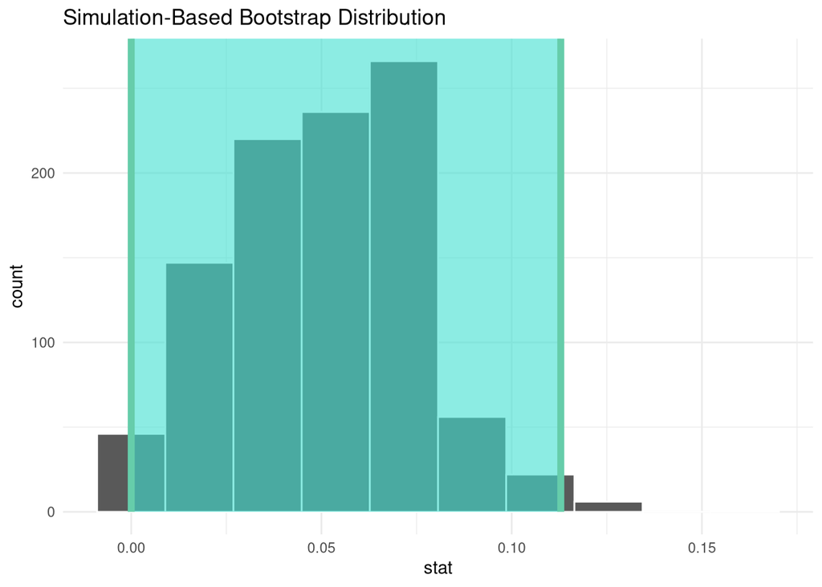

```r
# visualize the percentile interval

boot_dist |>
  visualize(bins = 10) +
  shade_confidence_interval(endpoints = percentile_95ci) +
  theme_minimal()
```

## Connect to Tests Using Randomization

We could also test whether or not the consultant’s rate of complications is less than 10%. Here, we cannot permute because we only have only one group, but we can simulate values from a binomial distribution with the probability parameter specified in Ho and number of trials equal to the sample size in order to get a null distribution.

$H_0:$ The consultant’s complication rate is 10%.

$H_a:$ The consultant’s complication rate is less than 10%.

```r
obs_prop <- livercomp |>
  specify(response = complication, success = "yes") |>
  calculate(stat = "prop")

null_dist <- livercomp |>
  specify(response = complication, success = "yes") |>
  hypothesize(null = "point", p = 0.10) |>
  generate(reps = 1000, type = "draw") |>
  calculate(stat = "prop")
```

```r
null_dist |>
  get_p_value(obs_stat = obs_prop, direction = "less")
```

```
# A tibble: 1 × 1
  p_value
    <dbl>
1   0.109
```

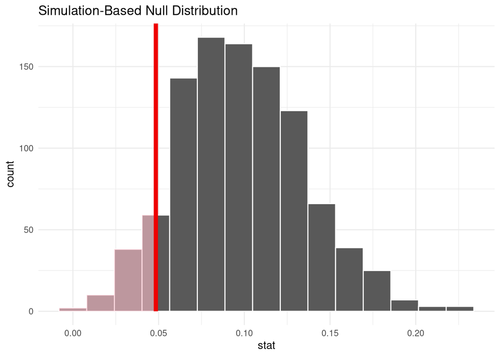

```r
null_dist |>
  visualize() +
  shade_p_value(obs_stat = obs_prop, direction = "left") +
  theme_minimal()
```